# Text Classification Workshop

Author

James Kelly

Published

December 10, 2024

## Required libraries

```r
library(tidyverse)
library(tidytext) # for unnest_tokens, get_stopwords and reorder_within
library(textstem) # for lemmatize_words
library(stringr) # Text cleaning
library(stringi) # Text cleaning
library(textclean) # for text cleaning functions like replace_contractions()
library(rsample) # for initial_split, training and testing
library(glmnet) # for cv.glm
library(textrecipes) # for recipe functions in modelling phase
library(hardhat) # For recipe functions
library(tidymodels) # For modelling (set_engine)
library(themis) # for optional sampling options
```

## Import data

The dataset at the following URL has 3 columns:

The first 50 rows are shown in the table below

```r
dat1 <- read_csv('https://raw.githubusercontent.com/brendanjodowd/company_desc/main/company_desc.csv', show_col_types = F)
glimpse(dat1)
```

```
Rows: 712
Columns: 3
$ id     <dbl> 1, 2, 3, 4, 5, 6, 7, 8, 9, 10, 11, 12, 13, 14, 15, 16, 17, 18, …
$ about  <chr> "Welcome to 123 Print, your go-to printers based in Balbriggan,…
$ sector <chr> "print", "transportation", "print", "transportation", "construc…
```

| id | about | sector |
| --- | --- | --- |
| 1 | Welcome to 123 Print, your go-to printers based in Balbriggan, Co. Dublin. As a trusted local and online print service, we pride ourselves on offering a wide range of on budget print and signage solut… | print |
| 2 | The delivery services of 247 Transnet are available for both business and personal customers. We provide an agency service for small businesses with same day, next and economy options available. Same … | transportation |
| 3 | With more than 25 years of experience and using our extensive in-house capabilities, we create a seamless brand, product and service experience. To do so, our areas of competence are networked in a fo… | print |
| 4 | Haulage & Storage North/South HAULAGE TANKER/ADR SPECIALISTS | transportation |
| 5 | A.Giffney and Sons Ltd. provides clients with the very latest in home renovations and home extensions. Our extremely experienced builders are available to clients all over North Dublin. We have been e… | construction |
| 6 | AJM Engineering are an Engineering and Manufacturing company in Co.Armagh, Northern Ireland. We have been in production for 11 years and support a lot of large companies such as Hyster-Yale forklifts,… | engineering |
| 7 | At AD Pottie & CO we focus on your future and what you want from your business. We aim to help you realise the future you want for your family and give you the framework of how to achieve this. We pro… | finance |
| 8 | A.J. Armstrong is a family owned business and since formed has gone from strength to strength whilst continuing to pride itself in the high standard of Repairing and Servicing JCB's the business has c… | construction |
| 9 | A1 Tradesmen Ltd prides itself in its quality workmanship, General building contractor, 24/7 reactive | construction |
| 10 | Abac Chartered Accountants based in Omagh Co Tyrone, and serving Strabane, Cookstown, Dungannon and Enniskillen, was started to help local businesses succeed. As well as providing all the normal servi… | finance |
| 11 | WE HAVE BEEN MANUFACTURING PRINT FOR ALMOST 30 YEARS NOW AND HAVE CUSTOMERS THROUGHOUT THE UK AND IRELAND. WE MANUFACTURE FOR A WIDE RANGE OF BUSINESS'S FROM PRINT MANAGEMENT COMPANIES TO INDIVIDUALLY… | print |
| 12 | With a well-established track record, Abacus Systems reduces operational risk, develops robust business processes with risk-free solutions to protect our customers businesses from issues such as; data… | it |
| 13 | Abbey Labels offers cost-effective print solutions to our wide spectrum of clients. We are a family run business delivering big company cost effectiveness and customer service. Our portfolio of labeli… | print |
| 14 | Founded in 1983, Abbey Woods specialise in the supply of Accoya, Hardwood and Softwood Timber, Hardwood Decking, Composite Decking, Claddings, Worktops and Wood Components for use in a variety of mark… | construction |
| 15 | At Abbeyset Print & Design we create beautiful and affordable print graphics logo and brand identity. | print |
| 16 | Acara Concepts Ltd is a distributor of natural and ecological thermal and acoustic insulation materials which offer excellent performance. Acara Concepts was established in 2007 as a small family busi… | construction |
| 17 | Search and discover. It's what we do. Search for the best people and discover the best talent. We've been searching and discovering on behalf of our clients for over 30 years and it's a skill we apply… | finance |
| 18 | We supply a large range of physical security products. These products include; security roller shutters, insulated shutters, fire rated shutters, commercial shutters, industrial roller shutters, retra… | engineering |
| 19 | Ace Fixings Ltd is a leading independent distributor and stockist of fixings and professional power tools from Bosch, Makita, Panasonic, Paslode, Fein, Trend and more. We stock a huge range of tools a… | industry |
| 20 | With 19th century origins, Ateliers de Constructions Electriques de Charleroi (ACEC) was originally a Belgian manufacturer of electrical generation , transmission, lighting and industrial equipment. A… | electrical |
| 21 | Since 1980 we have been providing signs & sinage to industry throughout the greater Dublin Area. | print |
| 22 | FOUNDED IN 1994 EXPERIENCED, DUBLIN BASED ELECTRICIANS With over 40 years' experience in the electrical trade, the team of electricians at Active Electrical have built up a reputation for providing a … | electrical |
| 23 | Ad-Vance Engineering is a U.K. specialist precision engineering company, based in Northern Ireland, specialising in bespoke injection moulding tools for the plastics manufacturing industry across the … | industry |
| 24 | Adept Accounting Services is headed up by Alison Furney, a fully qualified Chartered Accountant with over 25 years of experience working closely with small company directors, entrepreneurs & family ow… | finance |
| 25 | Advanced labels We are an AA+ BRC Accredited label Printer Suppling quality labels to Irish business for over 30 years. We specialise in Retail, Food, Beverage, and Pharmaceutical Labelling Printing d… | print |
| 26 | Advanced Services Ltd was set up in 1989, originally as a metal stockists and distributor. It is a family owned business, Randal Logue and his wife Marian are the company Directors. Lena Anderson is o… | print |
| 27 | AECOM is a global network of experts working with clients, communities and colleagues to develop and implement innovative solutions to the world's most complex challenges. Delivering clean water and e… | construction |
| 28 | Founded in the early 1970s, AEF Limited began life as Auto Engineering Factors in Dromartin, South County Dublin. Over the past 36 years it has established itself as one of Ireland's leading engineeri… | engineering |
| 29 | BUSINESS LINES CALLS & MOBILES We choose only the best solutions for our clients with savings and efficiency included in our consultation. Offering SIP lines and services including free calls and reco… | it |
| 30 | TaxAssist Accountants Ballymena provides a wide range of accountancy services including tax returns, annual accounts, payroll and bookkeeping. TaxAssist Accountants in Ballymena are a part of the larg… | finance |
| 31 | We offer different kind of met fabracation services from kitchen installations commercial and repairs to preventative maintenance and 24/7 emergency service, our properly trained, skilled and experien… | engineering |
| 32 | With Airfibre you get Established 2008 to deliver wireless Direct Internet Access (DIA) Leased Lines to Businesses in Ireland. Services expanded to include Managed Firewall as a Service (FaaS) and Man… | it |
| 33 | AKTA Cleaning Supplies Ltd was established in 1986 and has been run as a family enterprise since its inception. We supply a wide range of the leading cleaning chemicals & detergents, paper products, r… | industry |
| 34 | At Alan Keane & Co we value the strategic impact of our our partnership and we use this to our client's advantage. Our proposition is fundamentally based on using the respective skills, experience and… | finance |
| 35 | At Aldor Control Services we don't just provide doors - we provide solutions. If you're in the market for industrial doors, roller shutters, garage doors, traffic barriers, pedestrian access products,… | construction |
| 36 | Founded in 1982 by John Duhy, Alert Engineering is one of Ireland's best known makers of quality staircases, fire escapes, attic access and balustrading We are also Ireland's sole supplier of JOMY fir… | engineering |
| 37 | Alexander (Plant) Ltd is an integral part of the Alexander Group of companies which have been in business since 1972. Our head office is located in Omagh, Co Tyrone and we work throughout the UK and I… | construction |
| 38 | We thrive on product solving and sourcing unusual, innovative solutions in a reliable and dependable manner. If we can't get it, it simply can't be found. We are the hidden, but vital component in you… | engineering |
| 39 | Mission Statement- Providing a high quality, professional Fire Safety Consultancy Service to ensure our clients are fully compliant with current legislation, to protect premises and people. I have spe… | industry |
| 40 | With our head office in south Dublin we also have storage depots in North Dublin, Cork, Waterford, Limerick, Drogheda and Galway. We have continued to grow and in 2019 we delivered in excess of 100 mi… | print |
| 41 | We are a family run business located in the Whitestown Business Park, just minutes form the Square Shopping Center in Tallaght. We specialize in the supply of workwear, personal protective equipment, … | print |
| 42 | At Allied Graphics and Equipment we supply wide format printing, pre-press, print finishing equipment and consumables from a range of leading manufacturers. Over the past 31 years Allied Graphics and … | print |
| 43 | Allmetal Fasteners have over 50 years experience and have fast become one of Irelands leading suppliers of industrial fasteners. Suppling both standard & non standard fasteners, we offer a 24hr nation… | engineering |
| 44 | Based in Dun Laoghaire, Co. Dublin, Alphabet provides traditional offset and digital printing to provide a range of print solutions for businesses, large and small. Our skills and industry experience … | print |
| 45 | Amber Display LTD has been providing display signs throughout Dublin and all over Ireland for since 2004. We stock a wide variety sign products and services to suit your needs. We can design and make … | print |
| 46 | AMCA was established in 2002 and is a privately held company based in the United Kingdom. AMCA has been providing specialist engineering CAD services to the Construction Industry and Associated Profes… | engineering |
| 47 | AML Automation (Ireland) Ltd. is Ireland's premier specialist company in the design and distribution of low voltage electrical busbar trunking for all applications including rising mains, feeder from … | electrical |
| 48 | Established in 1992, Anchor Bay Construction Accessories are a leading supplier of specialist quality construction products in Ireland, supplying the construction, civil and precast industries. We are… | construction |
| 49 | Anchor Engineering was established in 2002 to distribute bearing and power transmission products to the UK and Irish markets. Since our formation we have become one of the largest independent stockist… | engineering |
| 50 | Anvil Manufacturing Engineering Ltd is an Engineering Company established in Dublin in 1972. We provide high standard quality finished products to a wide variety of Clients. Our drive to provide high … | engineering |

# Text Cleaning

Text Cleaning: A Crucial Step

When it comes to text classification, cleaning your text data is absolutely vital. The way you clean your text can vary a lot depending on what you’re working on and the specific needs of your project. While we won’t dive too deep into all the process here, it’s important to highlight just how crucial this step is.

Every corpus of text varies the expected standard in different ways. You should consider:

- Misspellings
- Contractions
- Domain specific Abbreviations
- Special characters
- Digits
- Punctuation
- Lemmatization
- Stemming
- Stopwords
- etc.

Proper text cleaning can make a huge difference in the performance of your models, ensuring your data is consistent and ready to work with. Always aim for standardization, e.g. ensure all misspellings, contractions, abbreviations of a given words is standardized to the same single entity/token. Below I presume the data is relatively clean, and will perform basic cleaning. For more information, this resource provides a very thorough explanation of these concepts: [Supervised Machine Learning for Text Analysis in R](https://smltar.com/).

## Custom Cleaning Framework

I define our custom text cleaning function that can be used as a framework that can be flashed out to do your own text cleaning:

```r
# Function to replace custom words/phrases in text based on a dictionary
replace_custom <- function(text, custom_dict) {
  for (word in names(custom_dict)) {
    # Replace all occurrences of the word (case-insensitive) with the corresponding value from the dictionary
    text <- str_replace_all(text, regex(word, ignore_case = TRUE), custom_dict[[word]])
  }
  return(text)
}

# Function to preprocess text with options for lemmatization, stemming, expanding contractions, and custom replacements:
preprocess_text <- function(text, lemmatize = FALSE, stem = FALSE, expand_contractions = FALSE, custom_dict = NULL) {

  # Expand contractions if the option is enabled
  if (expand_contractions) {
    text <- replace_contraction(text)
  }

  # Replace custom words/phrases if a custom dictionary is provided
  if (!is.null(custom_dict)) {
    text <- replace_custom(text, custom_dict)
  }

  # Lemmatize words if the option is enabled
  if (lemmatize) {
    text <- lemmatize_words(text)
  }

  # Stem words if the option is enabled
  if (stem) {
    text <- stem_words(text, language = "en")
  }

  # Perform various text cleaning steps
  text <- text %>%
    str_to_lower() %>%  # Convert text to lowercase
    str_remove_all("[[:punct:]]") %>%  # Remove punctuation
    str_remove_all("\\d") %>%  # Remove digits
    stri_trans_general("Latin-ASCII") %>%  # Transliterate to ASCII
    str_remove_all("[^[:alnum:]\\s]") %>%  # Remove non-alphanumeric characters
    str_squish()  # Remove extra whitespace

  return(text)
}
```

### Sample Cleaning

Below I fit the functions just defined. I show how you can make custom adjustments, for example is to replace `IT`, `I.T.` and `Information Technology` with `infotech`.These use regex patterns to match patterns in strings.

```r
# Apply the preprocess_text function to the 'about' column of dat1 dataframe
dat2 <- dat1 %>%
  mutate(about = about %>%
           preprocess_text(
             lemmatize = FALSE,  # Flag to lemmatize words, play about to see effect
             stem = FALSE,  # Flag to stem words
             expand_contractions = TRUE,  # Expand contractions using prebuilt dictionary
             custom_dict =  # Custom dictionary for replacements
               list(
                 "\bIT\b|\bI\\.T\\.\b|\b(I|i)nformation (T|t)echnology\b" = "infotech",
                 "\\bco\\.?\\b" = "county"  # Replace "co" or "co." with "county"
               )
             )
         )
```

## Examine the words frequencies

Now that we have cleaned our text, we can optionally see what terms are most common in each of the categories. This can be useful to see if there are many common words across all the categories, it may be indicative that it may be harder to classify. To do so, we must tokenize our text.

### Tokenization

Tokenization is the process of breaking down a text into smaller units called tokens. These tokens can be words, phrases, or even characters (usually words). Tokenization is used for converting the text into a format that can be processed by machine learning algorithms.

`unnest_tokens()` In R, the unnest_tokens() function from the tidytext package is used to tokenize text data. It takes a column of text and splits it into tokens, creating a tidy data frame where each token is a separate row.

We use tokenisation of our data and ggplot to do some basic frequency analysis:

[figure not shown]

```r
tokens_dat <- dat2 %>%
  unnest_tokens(word, about) %>%
  anti_join(get_stopwords())
top_freq <- dat2 %>%
  unnest_tokens(word, about) %>%
  anti_join(get_stopwords()) %>%
  count(sector, word) %>%
  slice_max(n, n = 8, by = sector)
ggplot(top_freq, aes(reorder_within(word, n, sector), n, fill = sector)) +
  geom_col(alpha = 0.8, show.legend = FALSE) +
  coord_flip() +
  facet_wrap(~sector, scales = "free") +
  tidytext::scale_x_reordered() +
  labs(x = NULL, y = NULL, title = "Top 10 Terms by Sector") +
  scale_fill_manual(values = rainbow(length(unique(top_freq$sector))))
```

## Examine the Classification Target Labels

Understanding the distribution of the target category must be considered in classification problems. It provides insights that can significantly impact the performance and reliability of your model. Here are some questions to investigate:

1. **Class Imbalance**: Is there a significant imbalance between the classes? How can we address this to ensure fair model performance (stratify test split etc.)?
2. **Model Evaluation**: Which metrics should we use to accurately evaluate the model’s performance, especially in the case of imbalanced data?
3. **Data Quality**: Are there any errors, missing values, or anomalies in the data? How can we clean the data to ensure it is representative and accurate? This is more relevant if a certain target category is systematically missing values, this is not relevant in this case.
4. **Business Insights**: What insights can we gain about the problem domain from the distribution of the target category? How can these insights inform decision-making?

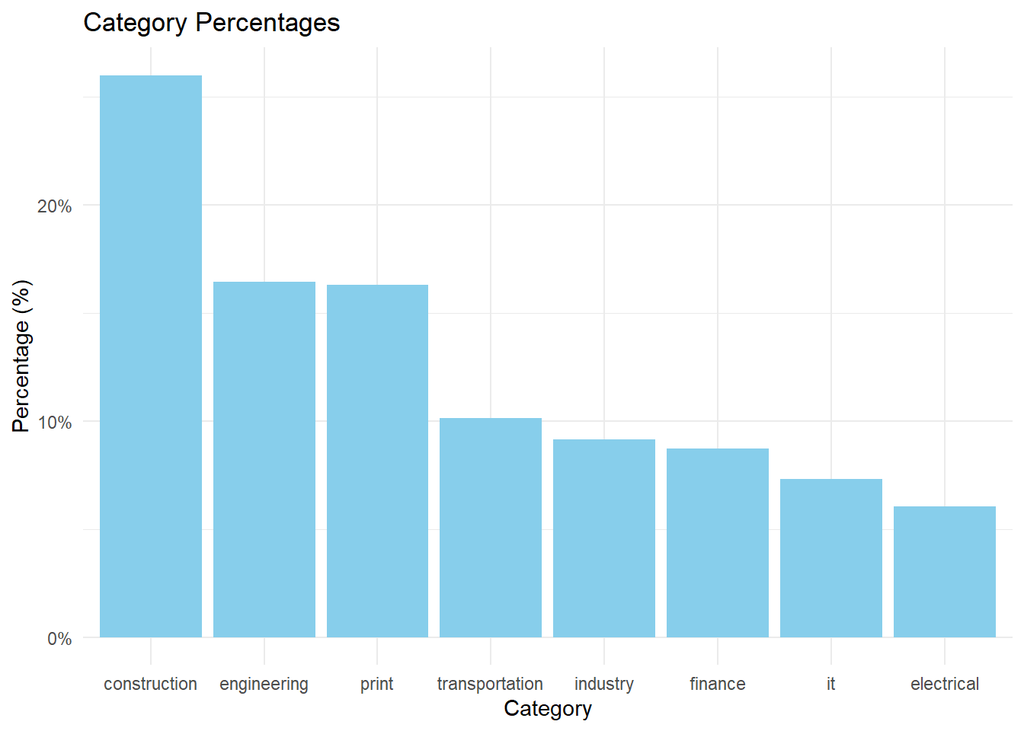

```r
barplot_target_category <- function(data, field, top_n = NULL) {
  # Count categories and calculate percentages
  category_counts <- data %>%
    count({{field}}, sort = TRUE) %>%
    mutate(percentage = n / sum(n) * 100)

  # If top_n is specified, filter the top n categories
  if (!is.null(top_n)) {
    category_counts <- category_counts %>% head(top_n)
  }

  # Plot
  ggplot(category_counts, aes(x = reorder({{field}}, -percentage), y = percentage)) +
    geom_bar(stat = "identity", fill = "skyblue") +
    labs(title = "Category Percentages", x = "Category", y = "Percentage (%)") +
    theme_minimal() +
    scale_y_continuous(labels = scales::percent_format(scale = 1))
}

barplot_target_category(dat2, field = sector)
```

Here we see we have imbalanced datasets so we will need to keep that in consideration when evaluating our model, e.g. our performance at classifying electrical may suffer due to less data availability.

# Multiclass Classification

**Algorithm Performance**: Many machine learning algorithms struggle with imbalanced data, making it hard to predict minority classes.

**Evaluation Metrics**: Metrics need to be adjusted to accurately reflect multiclass predictions. Using the standard accuracy may inflate the apparent performance of the classifier.

Handling Imbalanced Data:

1. **Down-sampling**: we reduce the number of observations in the majority classes to achieve a balanced distribution. (Also Up-sampling)
2. **Model Selection**: choose models more robust to imbalance like logistic regression
3. Play around with **classification threshold** (ROC curve)
4. **Custom Cost Functions**: we can an imbalances cost function (more complex, not necessary for most applications)

Here down sampling is a bad idea as we do not have much data to start with, so just monitor the performance of the lower balanced classes.

## Split the Data

Split into train and test. Stratify the split by target catefory to ensure there is an equivalent distribution of the classes in the split.

```r
set.seed(1234)
data_split = dat2 %>%
  initial_split(strata = sector)

data_train = training(data_split)
data_test = testing(data_split)
```

## Making a recipe

A recipe in the tidyverse is a sequence of data transformation steps, called “actions,” that you apply to your dataset to get it ready for analysis or machine learning.

**Purpose**: Transform raw data into a clean, analysis-ready format and provide a reproducible recipe for applying to similar data.

**Actions**: Recipes can include steps like cleaning, reshaping, joining, and aggregating data.

**Editing**: You can modify actions while the recipe is in an editable state and preview the results.

**Finalization**: Once applied to the full dataset, the recipe is set, but you can copy it to create new versions.

```r
# Folds: Make the cross validations fold for use later:
business_folds <- vfold_cv(data_train, v = 5)

# Defining the recipe:
business_rec <-
  recipe(sector ~ about, data = data_train)


# Add the vectorizing step:
business_rec <- business_rec %>%
  step_tokenize(about) %>%
  step_tokenfilter(about, max_tokens = tune(), min_times = 10) %>%
  step_tfidf(about) %>%
  #step_downsample(sector) # Skip due to low data availability.

print(business_rec)
```

```
── Recipe ──────────────────────────────────────────────────────────────────────
```

```
── Inputs
```

```
Number of variables by role
```

```
outcome:   1
predictor: 1
```

```
── Operations
```

```
• Tokenization for: about
```

```
• Text filtering for: about
```

```
• Term frequency-inverse document frequency with: about
```

## Specifying the Lasso Regression Model

We now define a multinomial logistic regression model with Lasso regularization, set it for classification, and uses glmnet engine for fitting. The penalty parameter will be tuned during training.

### Lasso Regression

Lasso (Least Absolute Shrinkage and Selection Operator) is a type of linear regression that uses L1 regularization.

### Key Points

- **Regularization**: Helps prevent overfitting by penalizing large coefficients.
- **Sparsity**: Can reduce the number of features by setting some coefficients to zero.
- **Model Interpretation**: Easier to interpret due to fewer predictors.

```r
# Specify the Model:
multi_spec <- multinom_reg(penalty = tune(), mixture = 1) %>%
  set_mode("classification") %>%
  set_engine("glmnet")

multi_spec
```

```
Multinomial Regression Model Specification (classification)

Main Arguments:
  penalty = tune()
  mixture = 1

Computational engine: glmnet
```

## Extending the recipe to a workflow

This code sets up a workflow for a machine learning model. It specifies that the data should be processed into a sparse matrix format, adds the previously defined recipe for preprocessing the data, and includes the model specification for our Lasso regression.

```r
sparse_bp <- default_recipe_blueprint(composition = "dgCMatrix") # sparse matrix for efficiency

multi_lasso_workflow <- workflow() %>%
  add_recipe(business_rec, blueprint = sparse_bp) %>% # add our recipe
  add_model(multi_spec) # add our model

multi_lasso_workflow
```

```
══ Workflow ════════════════════════════════════════════════════════════════════
Preprocessor: Recipe
Model: multinom_reg()

── Preprocessor ────────────────────────────────────────────────────────────────
3 Recipe Steps

• step_tokenize()
• step_tokenfilter()
• step_tfidf()

── Model ───────────────────────────────────────────────────────────────────────
Multinomial Regression Model Specification (classification)

Main Arguments:
  penalty = tune()
  mixture = 1

Computational engine: glmnet
```

## Hyperparameter Tuning

Hyperparameter tuning is the process of optimizing the hyperparameters of a machine learning model to improve its performance. Hyperparameters are parameters that are not learned from the data but are set prior to the training process. Examples include the learning rate in gradient descent, the number of trees in a random forest, and the regularization parameter in Lasso regression.

### Parameter Explanations

```r
# Define the grid tune:

# Tuning Grid:
grid_search <- grid_regular(
  penalty(range = c(-4, 0)),
  max_tokens(range = c(400, 800)),
  levels = c(penalty = 20, max_tokens = 3)
)

multi_lasso_rs <- tune_grid(
  multi_lasso_workflow,
  resamples = business_folds,
  grid = grid_search,
  control = control_grid(save_pred = T),
  metrics = metric_set(accuracy, sens, specificity, roc_auc, recall)
)
```

### Visualise tuning relationships

This visualization helps you understand how different combinations of regularization penalties and the number of tokens affect the model’s performance.

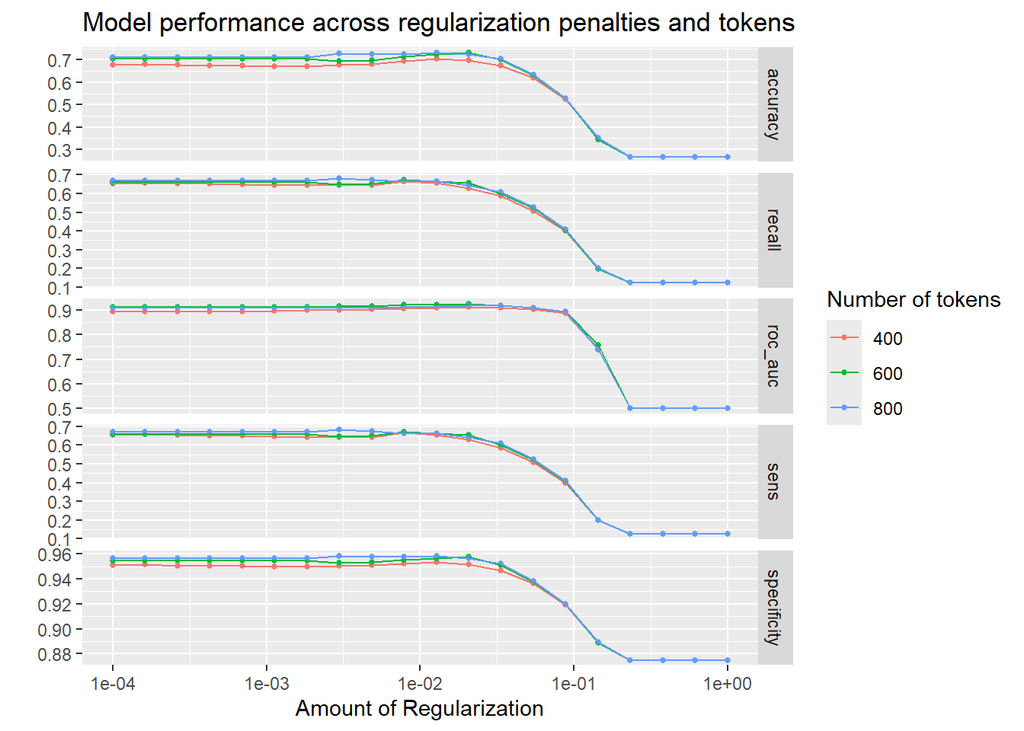

```r
autoplot(multi_lasso_rs) +
  labs(
    color = "Number of tokens",
    title = "Model performance across regularization penalties and tokens"
  )
```

# Evaluating the Model

When selecting the final model after hyperparameter tuning, there are several strategies you can use, especially when dealing with unbalanced classes. Here are some common approaches:

1. **Best Accuracy**: Select the model with the highest accuracy. This is straightforward but may not be ideal for unbalanced classes, as accuracy can be misleading if one class dominates.
2. **Best Balanced Accuracy**: Use balanced accuracy, which accounts for both sensitivity and specificity, making it more suitable for unbalanced classes.
3. **Best F1 Score**: The F1 score is the harmonic mean of precision and recall, providing a balance between the two. It’s useful when you need to balance false positives and false negatives.
4. **ROC-AUC**: The Area Under the Receiver Operating Characteristic Curve (ROC-AUC) measures the model’s ability to distinguish between classes. It’s effective for unbalanced datasets.
5. **Precision-Recall AUC**: The Area Under the Precision-Recall Curve is particularly useful for highly unbalanced datasets, focusing on the performance of the positive classes.

For simplicity, I’ll just chose accuracy in this case, but as a modeler you must decide what to prioritise with your model.

```r
choose_acc <- multi_lasso_rs %>%
  select_by_pct_loss(metric = "accuracy", penalty)

choose_acc
```

```
# A tibble: 1 × 3
  penalty max_tokens .config
    <dbl>      <int> <chr>
1 0.00298        800 Preprocessor3_Model08
```

```r
final_wf <- finalize_workflow(multi_lasso_workflow, choose_acc)
final_wf
```

```
══ Workflow ════════════════════════════════════════════════════════════════════
Preprocessor: Recipe
Model: multinom_reg()

── Preprocessor ────────────────────────────────────────────────────────────────
3 Recipe Steps

• step_tokenize()
• step_tokenfilter()
• step_tfidf()

── Model ───────────────────────────────────────────────────────────────────────
Multinomial Regression Model Specification (classification)

Main Arguments:
  penalty = 0.00297635144163132
  mixture = 1

Computational engine: glmnet
```

## Meausure against Test Set

Evaluating a model involves assessing its performance on a test dataset to understand how well it generalizes to new, unseen data. This process typically includes calculating various performance metrics and visualizing the results to gain insights into the model’s strengths and weaknesses.

```r
final_fitted <- last_fit(final_wf, data_split)

final_fitted %>%
  collect_metrics()
```

```
# A tibble: 3 × 4
  .metric     .estimator .estimate .config
  <chr>       <chr>          <dbl> <chr>
1 accuracy    multiclass     0.760 Preprocessor1_Model1
2 roc_auc     hand_till      0.953 Preprocessor1_Model1
3 brier_class multiclass     0.171 Preprocessor1_Model1
```

### Confusion Matrix

A confusion matrix is a table used to evaluate the performance of a classification model. It summarizes the counts of true positive (TP), true negative (TN), false positive (FP), and false negative (FN) predictions.

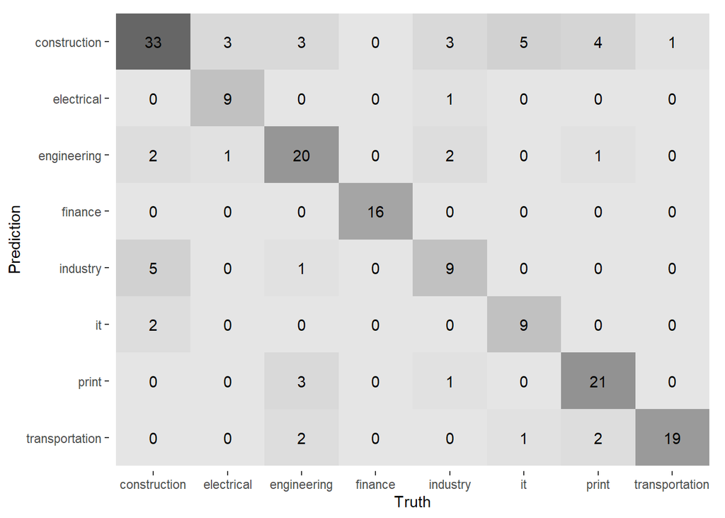

```r
final_fitted %>%
  collect_predictions() %>%
  conf_mat(truth = sector, estimate = .pred_class)  %>%
  autoplot(type = "heatmap")
```

Our model is performing relatively well considering the data availability. The model is predicting construction too frequently. This may be due to the fact that the model sees this class the most, or that the text data is most generic in this class. Further tuning (Nested CV with different model types like random forest etc.) or acquiring more data might yield better results.

# More Resources

This notebook references several resources, which should be accessed for more detailed breakdown of the concepts shown here:

1. [Supervised Machine Learning for Text Analysis in R](https://smltar.com/)
2. [Text Mining with R](https://www.tidytextmining.com/)
3. There is a nice video [TidyTuesday: Multiclass Classification using Tidymodels](https://www.youtube.com/watch?v=ntk_1xLQBwo) on youtube with the code shared on [Github](https://github.com/andrew-couch/Tidy-Tuesday/blob/master/Season%201/Scripts/TidyTuesdayMulticlassClassification.Rmd) which extends the approach in this notebook.

Contact james.kelly@cso.ie for further queries.

Thanks!